# Assignment 4

Student Name: Koki Sasagawa  
Student ID: 999054646

## Assignment 4: Rice SNPs and GWAS

This should be a knittable .Rmd file. Include this file, a .pdf and a .html when you turn in the assignment.

### Practice New functions:

```r
#Import data into object of current environment
fruit.size <- read.csv("./RiceSNPData/fruit_size.csv")
fruit.color <- read.csv("./RiceSNPData/fruit_color.csv")
fruit.shape <- read.csv("./RiceSNPData/fruit_shape.csv")

#Display Contents
fruit.size
fruit.color
fruit.shape

#Use the merge function to combine the different data frames into a single one
fruit.color.shape <- merge(fruit.color, fruit.shape, by="fruit")

#Display Contents
fruit.color.shape
```

**PRACTICE 1:**  
*a. What does “by” do? In the command above (hint: look at the help page for merge())*

> `by` specifies the column used for merging.

*b. Why are there only seven rows in the merged data set even though fruit.shape had nine? Read the help page for merge() to figure out how to keep all of the data in the original fruit.shape data sheet.*

> There are only seven rows instead of 9 because fruit.color only had 7 fruit entries. Since we are merging the two data frames by the column fruit, the 2 fruits in fruit.shapes are left out because it is not included in fruit.color.

```r
#Use the merge function to combine and keep all the rows.
fruit.color.shape <- merge(fruit.color, fruit.shape, by = "fruit", all = T)

#Display Contents
fruit.color.shape
```

*c. Merge fruit.size with fruit.color.shape, keeping all of the rows from each original sheet. Place the merged dataframe in fruit.all. Note that the column that you want to merge on for fruit size has a different name. Read help on merge() to figure out how to deal with this.*

```r
#Rename the column from name to fruit using colnames
colnames(fruit.size) <- c("fruit", "size")
fruit.all <- merge(fruit.size, fruit.color.shape, by = "fruit", all = T)

#Display Content
fruit.all
```

**Sorting and ordering data:**

We can use the `sort()` function to sort any single vector of data.

```r
sort(fruit.shape$fruit)

#Sort reverse alphabetical order
sort(fruit.shape$fruit, decreasing = T)
```

We can use the `order()` to tell us how we could reorder the items to obtain a sorted list.

```r
order(fruit.shape$fruit)
```

**PRACTICE 2:**  
reorder fruit.all so that the whole data.frame is sorted by fruit shape. Include the code:

```r
order(fruit.all$shape)
sort(fruit.all$shape)

#Using [], order the fruit.all by shape
fruit.all[order(fruit.all$shape),]
```

```r
fruit.all[order(fruit.all$size, fruit.all$shape),]
```

**Reshaping data:**  
In a long format, each row represents a single observation. The reshape library has the `melt()` function to covert wide to long.

```r
library(reshape2)
fruit.all

#id.var allows to specify which column holds the identification information. meas.far can allow specification of measurements
fruit.all.melt <- melt(fruit.all, id.var="fruit")
fruit.all.melt
```

**Applying funcions across rows or columns:**  
`apply()` takes at least 3 arguments where X is a data frame or matrix, MARGIN is whether to apply a function to each row (1) or each column (2), FUN is the function that you want to use.

```r
m <- matrix(rnorm(24),ncol=6)
m
apply(m,1,min)
```

```r
apply(m,1,mean)
```

### Lets get started with the real data

```r
data.geno <- read.csv("./RiceSNPData/Rice_44K_genotypes.csv.gz",
                      row.names=1, #this tells R to use the first column as row names
                      na.strings=c("NA","00")) #this tells R that missing data is denoted as "NA" or "00"
```

```r
head(data.geno[,1:20])
```

|  | X1_13147 | X1_73192 | X1_74969 | X1_75852 | X1_75953 | X1_91016 | X1_146625 | X1_149005 | X1_149754 | X1_151492 | X1_152899 | X1_172755 | X1_172923 | X1_173692 | X1_195327 | X1_199011 | X1_202999 | X1_203126 | X1_205867 | X1_212693 |
| --- | --- | --- | --- | --- | --- | --- | --- | --- | --- | --- | --- | --- | --- | --- | --- | --- | --- | --- | --- | --- |
| NSFTV1 | TT | TT | CC | GG | TT | AA | CC | TT | AA | AA | GG | CC | CC | AA | TT | TT | TT | AA | AA | GG |
| NSFTV3 | CC | CC | CC | AA | GG | NA | CC | GG | TT | GG | GG | CC | CC | TT | CC | TT | TT | CC | GG | TT |
| NSFTV4 | CC | CC | CC | AA | GG | GG | CC | GG | TT | GG | GG | CC | CC | TT | CC | TT | TT | CC | GG | TT |
| NSFTV5 | CC | CC | TT | GG | GG | AA | TT | GG | TT | AA | NA | CC | CC | AA | CC | TT | AA | CC | GG | GG |
| NSFTV6 | CC | CC | CC | AA | GG | GG | CC | GG | TT | GG | GG | CC | CC | TT | CC | TT | TT | CC | GG | TT |
| NSFTV7 | TT | TT | CC | GG | TT | AA | CC | TT | AA | AA | GG | CC | TT | AA | TT | TT | TT | AA | AA | GG |

```r
summary(data.geno[,1:20])
```

```
 X1_13147   X1_73192   X1_74969   X1_75852 X1_75953   X1_91016   X1_146625  X1_149005  X1_149754
 CC  :124   CC  :125   CC  :349   AA: 58   GG  :123   AA  :312   CC  :349   GG  :123   AA  :287
 TT  :288   TT  :287   TT  : 63   GG:355   TT  :288   GG  : 34   TT  : 63   TT  :288   TT  :118
 NA's:  1   NA's:  1   NA's:  1            NA's:  2   NA's: 67   NA's:  1   NA's:  2   NA's:  8
 X1_151492  X1_152899  X1_172755  X1_172923  X1_173692  X1_195327  X1_199011 X1_202999  X1_203126
 AA  :352   AA  : 38   CC  :396   CC  :313   AA  :347   CC  :144   CC: 45    AA  : 61   AA  :256
 GG  : 59   GG  :344   TT  : 16   TT  : 94   TT  : 54   TT  :254   TT:368    TT  :347   CC  :149
 NA's:  2   NA's: 31   NA's:  1   NA's:  6   NA's: 12   NA's: 15             NA's:  5   NA's:  8
 X1_205867  X1_212693
 AA  :259   GG  :322
 GG  :152   TT  : 89
 NA's:  2   NA's:  2
```

Create a data subset that contains a random sample of 2500 SNPs

```r
#data.geno.2500 <- sample(data.geno, 2500)
dim(data.geno.2500)
```

```
[1]  413 2500
```

Create a MDS plot with our smaller subset

```r
#convert the data matrix to numbers
#geno.numeric <- data.matrix(data.geno.2500)
head(geno.numeric[,1:20])
```

```
       X2_15844766 X8_22540338 X2_7225728 X11_18580605 X11_5747290 X6_7699100 X2_21043673
NSFTV1           2           2          1            2           1          1           2
NSFTV3           1           1          2            1           3          2           2
NSFTV4           1           1          2            1           1          1          NA
NSFTV5           2           1          1            2           1          1           2
NSFTV6           1           2          2            1           1          1          NA
NSFTV7           2           2          2            1           3          1           2
       X5_28979029 X5_611562 X1_22997452 X11_10307739 X2_2844680 X12_9907996 X3_3218345 X1_42628875
NSFTV1           1         2          NA            2          1           2          2           1
NSFTV3           1         2           1            1          2           2          2           1
NSFTV4           1         2           2            2          1           2          1           1
NSFTV5           1         2           1            2          2           2          2           1
NSFTV6           1         2           2            2          1           2          1           1
NSFTV7           1         2           1            2          1           2          2           1
       X1_7179947 X9_18556099 X3_23044516 X12_25775785 X5_24772917
NSFTV1          2           1           1            3           2
NSFTV3          2           1           2            3           1
NSFTV4          1           1           2            1           1
NSFTV5         NA           1           1            3           2
NSFTV6         NA           1          NA            1           1
NSFTV7          2           1           1            3           2
```

```r
#calculate the Euclidian distance between each rice variety
genDist <- as.matrix(dist(geno.numeric))
```

```r
#perform the multi-dimensional scaling
geno.mds <- as.data.frame(cmdscale(genDist))
head(geno.mds) #now we have 2 dimensions
```

|  | V1 | V2 |
| --- | --- | --- |
| NSFTV1 | 16.569532 | -1.078799 |
| NSFTV3 | -24.647602 | 10.017045 |
| NSFTV4 | -19.133902 | -11.226454 |
| NSFTV5 | 2.656613 | -4.445264 |
| NSFTV6 | -18.105631 | -10.870482 |
| NSFTV7 | 10.294525 | 1.601811 |

**EXERCISE 1:** Is there any evidence for populations structure (different sub populations)? If so, how many sub populations do you think the MDS plot reveals? What do you make of the individuals that are between the major groups? (Include your plot and code)

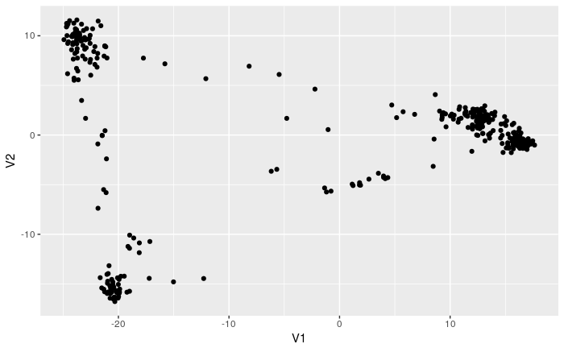

```r
library(ggplot2)
riceMDS <- ggplot(geno.mds, aes(x = V1, y = V2))
riceMDS + geom_point()
```

> The MDS graph shows 3 groups of SNPs, thus suggesting there are 3 sub populations. Each of these dots represents a rice strain and we are comparing 2500 random SNPs (reduction from the original 44000). The rice strains that are grouped together thus share similar genotypes of SNPs. The individuals that are in between the major groups are strains of rice are variants that do not share the same genotype of SNPs as the 3 sub populations. These rice strains are perhaps mutant strains that have gained a change in SNP genotype.

**EXERCISE 2:**

- Use the `read.csv()` `head()` and `summary()` functions that you learned earlier to import and look at this file. Import the file into an object called “data.pheno”.
- Use merge() to merge the MDS scaled genotype data with the phenotype data. Here the column that we are merging on is the “row.name” column. So you can use `by="row.names"` or `by=1` in your call to merge. Use summary and head to look at the new object and make sure that it is as you expect.
- Include your code in the .Rmd

```r
data.pheno <- read.csv("./RiceSNPData/RiceDiversity.44K.MSU6.Phenotypes.csv",row.names=1,na.strings=c("NA","00"))

data.geno.pheno <- merge(geno.mds, data.pheno, by=0, All = T)
head(data.geno.pheno)
```

|  | Row.names | V1 | V2 | Accession_Name | Country_of_Origin | Region | Alu.Tol | Flowering.time.at.Arkansas | Flowering.time.at.Faridpur | Flowering.time.at.Aberdeen | FT.ratio.of.Arkansas.Aberdeen | FT.ratio.of.Faridpur.Aberdeen | Culm.habit | Leaf.pubescence | Flag.leaf.length | Flag.leaf.width | Awn.presence | Panicle.number.per.plant | Plant.height | Panicle.length | Primary.panicle.branch.number | Seed.number.per.panicle | Florets.per.panicle | Panicle.fertility | Seed.length | Seed.width | Seed.volume | Seed.surface.area | Brown.rice.seed.length | … |
| --- | --- | --- | --- | --- | --- | --- | --- | --- | --- | --- | --- | --- | --- | --- | --- | --- | --- | --- | --- | --- | --- | --- | --- | --- | --- | --- | --- | --- | --- | --- |
| 1 | NSFTV1 | 16.56953 | -1.0787988 | Agostano | Italy | Europe | 0.730 | 75.08333 | 64 | 81 | 0.9269547 | 0.7901235 | 4.000000 | 1 | 28.37500 | 1.283333 | 0 | 3.068053 | 110.91667 | 20.48182 | 9.272727 | 4.785975 | 4.914658 | 0.879 | 8.064117 | 3.685183 | 2.587448 | 3.914120 | 5.794542 | … |
| 2 | NSFTV10 | 17.04054 | -0.8204474 | Baghlani Nangarhar | Afghanistan | Mid East | 0.902 | 89.00000 | 55 | 74 | 1.2027027 | 0.7432432 | 3.000000 | NA | 27.90000 | 1.000000 | 1 | 3.650658 | 83.00000 | 22.16667 | 10.333333 | 4.110874 | 4.733270 | 0.537 | 7.859000 | 3.233250 | 2.265361 | 3.729249 | 5.088267 | … |
| 3 | NSFTV100 | 15.11382 | 1.4328584 | Lacrosse | United States | America | 0.800 | 84.11111 | 78 | 122 | 0.6894353 | 0.6393443 | 1.666667 | 0 | 27.62222 | 1.611111 | 0 | 2.978925 | 114.88889 | 23.94444 | 11.555556 | 5.032614 | 5.340738 | 0.735 | 8.138033 | 3.382633 | 2.440978 | 3.850531 | 5.944467 | … |
| 4 | NSFTV101 | 11.42892 | 2.3895538 | Lemont | United States | America | 0.630 | 86.16667 | 79 | 88 | 0.9791667 | 0.8977273 | 3.000000 | 0 | 27.62500 | 1.450000 | 0 | 2.818398 | 86.16667 | 27.45000 | 11.083333 | 4.894101 | 5.209031 | 0.730 | 9.632392 | 2.644467 | 2.121810 | 3.778742 | 7.147025 | … |
| 5 | NSFTV102 | -22.55710 | 10.0444979 | NA | NA | NA | 0.440 | NA | NA | 165 | NA | NA | 3.000000 | NA | 27.85000 | 1.100000 | 1 | 3.481240 | 105.50000 | 30.75000 | 10.500000 | 4.600158 | 4.867534 | 0.765 | 9.805500 | 2.469600 | 2.030632 | 3.750804 | 7.072600 | … |
| 6 | NSFTV103 | 15.72071 | 0.2261091 | Luk Takhar | Afghanistan | Mid East | 0.550 | 84.00000 | 78 | 108 | 0.7777778 | 0.7222222 | 2.500000 | 1 | 30.17500 | 1.050000 | 0 | 2.957511 | 95.08333 | 24.13333 | 9.777778 | 4.881538 | 4.998900 | 0.889 | 7.528083 | 3.534583 | 2.404007 | 3.784157 | 5.298917 | … |

```r
summary(data.geno.pheno)
```

```
  Row.names               V1               V2                 Accession_Name     Country_of_Origin
 Length:413         Min.   :-24.92   Min.   :-16.7781   Azucena      :  2    United States: 41
 Class :AsIs        1st Qu.:-20.85   1st Qu.: -1.0282   Carolina Gold:  2    China        : 28
 Mode  :character   Median : 11.62   Median :  0.6783   Dom Sufid    :  2    India        : 27
                    Mean   :  0.00   Mean   :  0.0000   M-202        :  2    Bangladesh   : 24
                    3rd Qu.: 15.20   3rd Qu.:  2.5807   Moroberekan  :  2    Japan        : 17
                    Max.   : 17.64   Max.   : 11.5930   (Other)      :373    (Other)      :246
                                                        NA's         : 30    NA's         : 30
     Region      Alu.Tol       Flowering.time.at.Arkansas Flowering.time.at.Faridpur
 America:83   Min.   :0.0300   Min.   : 54.50             Min.   : 39.00
 E Asia :73   1st Qu.:0.4000   1st Qu.: 79.75             1st Qu.: 66.00
 S Asia :64   Median :0.6035   Median : 87.71             Median : 74.00
 Africa :39   Mean   :0.5874   Mean   : 87.94             Mean   : 71.77
 Europe :34   3rd Qu.:0.7500   3rd Qu.: 96.83             3rd Qu.: 78.00
 (Other):78   Max.   :1.3500   Max.   :150.50             Max.   :110.00
 NA's   :42   NA's   :43       NA's   :39                 NA's   :108
 Flowering.time.at.Aberdeen FT.ratio.of.Arkansas.Aberdeen FT.ratio.of.Faridpur.Aberdeen
 Min.   : 45.0              Min.   :0.3724                Min.   :0.3459
 1st Qu.: 81.5              1st Qu.:0.7975                1st Qu.:0.6838
 Median : 99.0              Median :0.8960                Median :0.7720
 Mean   :107.1              Mean   :0.8949                Mean   :0.7711
 3rd Qu.:114.0              3rd Qu.:1.0195                3rd Qu.:0.8671
 Max.   :306.0              Max.   :1.7031                Max.   :1.2885
 NA's   :54                 NA's   :64                    NA's   :109
   Culm.habit    Leaf.pubescence  Flag.leaf.length Flag.leaf.width   Awn.presence
 Min.   :1.000   Min.   :0.0000   Min.   :15.42    Min.   :0.5917   Min.   :0.0000
 1st Qu.:3.000   1st Qu.:1.0000   1st Qu.:26.62    1st Qu.:1.0400   1st Qu.:0.0000
 Median :4.000   Median :1.0000   Median :30.05    Median :1.1833   Median :0.0000
 Mean   :4.228   Mean   :0.8507   Mean   :30.63    Mean   :1.2217   Mean   :0.2222
 3rd Qu.:5.500   3rd Qu.:1.0000   3rd Qu.:34.55    3rd Qu.:1.4111   3rd Qu.:0.0000
 Max.   :9.000   Max.   :1.0000   Max.   :49.44    Max.   :1.8917   Max.   :1.0000
 NA's   :29      NA's   :125      NA's   :36       NA's   :36       NA's   :44
 Panicle.number.per.plant  Plant.height    Panicle.length  Primary.panicle.branch.number
 Min.   :2.234            Min.   : 67.75   Min.   :15.63   Min.   : 5.556
 1st Qu.:2.931            1st Qu.: 99.75   1st Qu.:22.24   1st Qu.: 8.667
 Median :3.242            Median :117.50   Median :24.19   Median : 9.917
 Mean   :3.247            Mean   :116.58   Mean   :24.37   Mean   : 9.943
 3rd Qu.:3.558            3rd Qu.:131.39   3rd Qu.:26.45   3rd Qu.:11.111
 Max.   :4.172            Max.   :194.33   Max.   :35.68   Max.   :17.000
 NA's   :41               NA's   :30       NA's   :38      NA's   :38
```

[output cut: 25 more lines]

```
 dark :  8   dark : 34      Min.   :2.330              Min.   :0.000    Min.   : 0.00
 light:369   light:343      1st Qu.:5.998              1st Qu.:2.000    1st Qu.:16.70
 NA's : 36   NA's : 36      Median :7.165              Median :5.000    Median :21.13
                            Mean   :6.936              Mean   :5.039    Mean   :19.88
                            3rd Qu.:8.167              3rd Qu.:8.000    3rd Qu.:23.97
                            Max.   :9.000              Max.   :9.000    Max.   :27.96
                            NA's   :73                 NA's   :28       NA's   :12
 Alkali.spreading.value Protein.content
 Min.   :2.000          Min.   : 6.500
 1st Qu.:5.403          1st Qu.: 7.950
 Median :6.083          Median : 8.450
 Mean   :5.974          Mean   : 8.593
 3rd Qu.:6.938          3rd Qu.: 9.050
 Max.   :7.000          Max.   :14.100
 NA's   :10             NA's   :20
```

**EXERCISE 3:** Prepare three different plots to explore if subgroups vary by 1) Amylose content; 2) Pericarp color; 3) Region. Do any of these seem to be associated with the different population groups? Briefly discuss.

*Hint 1* use `color=` argument to `qplot` or `ggplot` to color the point by the different traits  
*Hint 2* use `size=I(3)` as an argument to increase the point size (you can play with different values)  
*Hint 3* when plotting the Region data, the colors will be easier to interpret if you include the following at the end of the line with your qplot command: `+ scale_color_brewer(type="div")` This specifies that a diverging set of colors is used. (Try plotting with and without this).

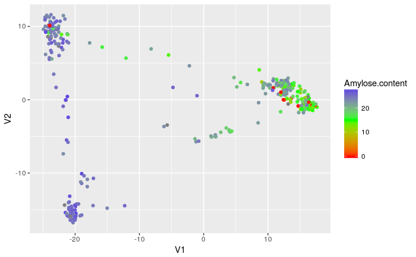

```r
#Amylose MDS
amylose <- ggplot(data.geno.pheno, aes(x = V1, y = V2, color = Amylose.content))
amylose + geom_point() + scale_colour_gradient2(low = "red", mid = "green",
  high = "blue", midpoint = 15, guide = "colourbar")
```

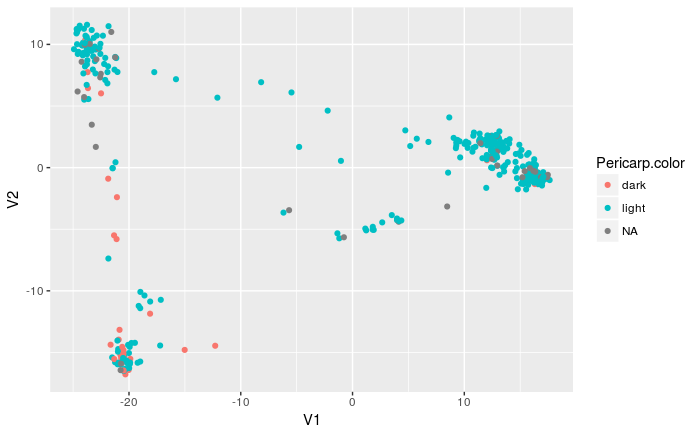

```r
#Pericarp MDS
pericarp <- ggplot(data.geno.pheno, aes(x = V1, y = V2, color = Pericarp.color))
pericarp + geom_point()
```

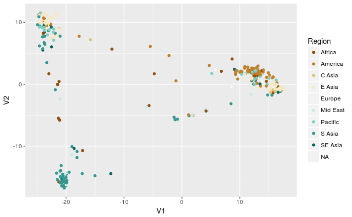

```r
#Region MDS
region <- ggplot(data.geno.pheno, aes(x = V1, y = V2, color = Region))
region + geom_point() + scale_color_brewer(type="div")
```

**EXERCISE 4:** Re plot the MDS data, but include the population assignment in an informative way. How do the populations assignments relate to the MDS plot? PSMix: Assigning varieties to populations. From the MDS there looks like there is structure in our population, we will assign individuals to specific populations classes with PSMix package.

Convert our genotypes to PSMix format (separate row for each allele)

```r
#Convert to character matrix.  The apply function applies a function (in this case as.character()) either to every column or every row in the data.
data.geno.2500.c <- apply(data.geno.2500,2,as.character)

#Create a new Matrix to hold reformatted data
data.geno.2500.ps <- matrix("",nrow=nrow(data.geno.2500.c)*2,ncol=ncol(data.geno.2500.c))

#for each row of genotypes, create 2 rows, one with the first allele and one with the second allele.
for (i in 1:nrow(data.geno.2500.c)) {
  data.geno.2500.ps[(i-1)*2+1,] <- substr(data.geno.2500.c[i,],1,1)
  data.geno.2500.ps[(i-1)*2+2,] <- substr(data.geno.2500.c[i,],2,2)
  }
```

```r
library(PSMix)
load("./RiceSNPData/ps4.2500.RData")

#run on K=4 popultions and 2500 markers; may take 15-30 minutes
#system.time(ps4 <- PSMix(K=4,data.geno.2500.ps,eps=1e-05,verbose=T))
#save(ps4,file="../data/ps4.2500.RData")

#2500 markers K = 5 > 1 hour run time
#system.time(ps5 <- PSMix(K=5,data.geno.2500.ps,eps=1e-05,verbose=T))
#save(ps5,file="../data/ps5.2500.RData")
```

Examine Output

```r
names(ps4) #Show us elements within ps4
```

```
[1] "AmPr" "AmId"
```

```r
head(ps4$AmPr)
```

```
               pr1           pr2           pr3           pr4
[1,]  3.906153e-74  1.000000e+00 4.940656e-324 4.940656e-324
[2,] 1.632141e-223 9.326173e-252  1.000000e+00 1.571730e-111
[3,]  3.199112e-39  1.623725e-82  1.263693e-01  8.736307e-01
[4,]  3.846553e-01  2.629090e-01  3.702799e-02  3.154077e-01
[5,]  1.655290e-02  2.043686e-34  1.336814e-01  8.497657e-01
[6,]  9.255409e-01  2.628336e-02  4.817578e-02  7.551204e-29
```

```r
round(head(ps4$AmPr), 3) #Round to 3 decimal places
```

```
       pr1   pr2   pr3   pr4
[1,] 0.000 1.000 0.000 0.000
[2,] 0.000 0.000 1.000 0.000
[3,] 0.000 0.000 0.126 0.874
[4,] 0.385 0.263 0.037 0.315
[5,] 0.017 0.000 0.134 0.850
[6,] 0.926 0.026 0.048 0.000
```

Each row in the AmPr table is an individual and each column represents one of the hypothesized populations. Genomes with substantial contributions from two ancestral genomes are said to be admixed.

The second component, AmID, shows an assignment of each individual to a signle ancestral population.

```r
head(ps4$AmId)
```

```
[1] 2 3 4 1 4 1
```

```r
table(ps4$AmId)
```

```
  1   2   3   4
133 117  96  67
```

```r
ps4.df <- as.data.frame(cbind(round(ps4$AmPr,3),ps4$AmId))
head(ps4.df) #look at the new data frame
```

|  | pr1 | pr2 | pr3 | pr4 | V5 |
| --- | --- | --- | --- | --- | --- |
| 1 | 0.000 | 1.000 | 0.000 | 0.000 | 2 |
| 2 | 0.000 | 0.000 | 1.000 | 0.000 | 3 |
| 3 | 0.000 | 0.000 | 0.126 | 0.874 | 4 |
| 4 | 0.385 | 0.263 | 0.037 | 0.315 | 1 |
| 5 | 0.017 | 0.000 | 0.134 | 0.850 | 4 |
| 6 | 0.926 | 0.026 | 0.048 | 0.000 | 1 |

```r
#Next add useful column names
colnames(ps4.df) <- c(paste("pop",1:(ncol(ps4.df)-1),sep=""),"popID")
head(ps4.df) #look at the new data frame
```

|  | pop1 | pop2 | pop3 | pop4 | popID |
| --- | --- | --- | --- | --- | --- |
| 1 | 0.000 | 1.000 | 0.000 | 0.000 | 2 |
| 2 | 0.000 | 0.000 | 1.000 | 0.000 | 3 |
| 3 | 0.000 | 0.000 | 0.126 | 0.874 | 4 |
| 4 | 0.385 | 0.263 | 0.037 | 0.315 | 1 |
| 5 | 0.017 | 0.000 | 0.134 | 0.850 | 4 |
| 6 | 0.926 | 0.026 | 0.048 | 0.000 | 1 |

For plotting it will be helpful to order the samples based on population for each individual. This is done using apply(), which applies functios across every row or column of a dataframe.

```r
maxGenome <- apply(ps4$AmPr,1,max)
#now we order the varieties by their prediced population membership and their degree of admixture.
ps4.df <- ps4.df[order(ps4.df$popID,-maxGenome),]
#Add a column for sample index
ps4.df$sampleID <- factor(1:413)
head(ps4.df)
```

|  | pop1 | pop2 | pop3 | pop4 | popID | sampleID |
| --- | --- | --- | --- | --- | --- | --- |
| 12 | 1 | 0 | 0 | 0 | 1 | 1 |
| 18 | 1 | 0 | 0 | 0 | 1 | 2 |
| 20 | 1 | 0 | 0 | 0 | 1 | 3 |
| 21 | 1 | 0 | 0 | 0 | 1 | 4 |
| 22 | 1 | 0 | 0 | 0 | 1 | 5 |
| 23 | 1 | 0 | 0 | 0 | 1 | 6 |

Now take the data from wide to long format as ggplot needs one observation per row.

```r
library(reshape2)
ps4.df.melt <- melt(ps4.df,id.vars=c("popID","sampleID"))
head(ps4.df.melt) #look a the melted data set.
```

|  | popID | sampleID | variable | value |
| --- | --- | --- | --- | --- |
| 1 | 1 | 1 | pop1 | 1 |
| 2 | 1 | 2 | pop1 | 1 |
| 3 | 1 | 3 | pop1 | 1 |
| 4 | 1 | 4 | pop1 | 1 |
| 5 | 1 | 5 | pop1 | 1 |
| 6 | 1 | 6 | pop1 | 1 |

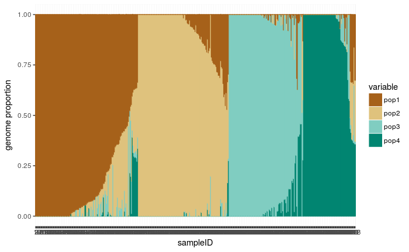

```r
library(ggplot2)
pl <- ggplot(aes(x=sampleID, y=value, color=variable, fill=variable), data=ps4.df.melt)
pl <- pl + geom_bar(stat="identity")
pl <- pl + ylab("genome proportion") + scale_color_brewer(type="div") + scale_fill_brewer(type="div")
pl
```

```r
geno.mds$popID <- factor(ps4$AmId)
head(geno.mds$popID)
```

```
[1] 2 3 4 1 4 1
Levels: 1 2 3 4
```

```r
colnames(ps4$AmPr) <- paste("pr",1:4,sep="")
geno.mds <- cbind(geno.mds,ps4$AmPr)
head(geno.mds)
```

|  | V1 | V2 | popID | pr1 | pr2 | pr3 | pr4 |
| --- | --- | --- | --- | --- | --- | --- | --- |
| NSFTV1 | 16.569532 | -1.078799 | 2 | 3.906153e-74 | 1.000000e+00 | 4.940656e-324 | 4.940656e-324 |
| NSFTV3 | -24.647602 | 10.017045 | 3 | 1.632141e-223 | 9.326173e-252 | 1.000000e+00 | 1.571730e-111 |
| NSFTV4 | -19.133902 | -11.226454 | 4 | 3.199112e-39 | 1.623725e-82 | 1.263693e-01 | 8.736307e-01 |
| NSFTV5 | 2.656613 | -4.445264 | 1 | 3.846553e-01 | 2.629090e-01 | 3.702799e-02 | 3.154077e-01 |
| NSFTV6 | -18.105631 | -10.870482 | 4 | 1.655290e-02 | 2.043686e-34 | 1.336814e-01 | 8.497657e-01 |
| NSFTV7 | 10.294525 | 1.601811 | 1 | 9.255409e-01 | 2.628336e-02 | 4.817578e-02 | 7.551204e-29 |

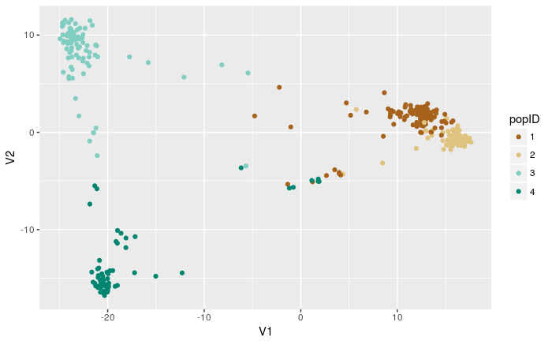

```r
#PopulationMDS
population <- ggplot(geno.mds, aes(x = V1, y = V2, color = popID))
population + geom_point() + scale_color_brewer(type="div")
```

> This MDS plot shows where the individual plants group together in subpopulations. The sub-populations 1 and 2 are closely related, while 3 and 4 are diverged populations.

```r
save(data.pheno,geno.mds,file="data_from_SNP_lab.Rdata")
```

**Exercise 5:**

- Plot your chosen trait data
- as a **single histogram** for all of the data
- as **separate histograms** for each of the 4 population assignments made by PSMix
- as a **boxplot** separated by population.
- Based on these histograms do you think that your trait varies by population?
- **BONUS** Try using the “violin” geom. What is this showing?

Hint: you will need to use a different binwidth (or don’t specify it at all and let R choose the default). Hint: the relevant column names for population are “popID”.

Merge Data of amylose

```r
data.pheno.mds <- merge(geno.mds,data.pheno,by="row.names",all=T) #even if you already have this object, rerun it so that the AmID and pr1-4 columns are brought in
head(data.pheno.mds)
```

|  | Row.names | V1 | V2 | popID | pr1 | pr2 | pr3 | pr4 | Accession_Name | Country_of_Origin | Region | Alu.Tol | Flowering.time.at.Arkansas | Flowering.time.at.Faridpur | Flowering.time.at.Aberdeen | FT.ratio.of.Arkansas.Aberdeen | FT.ratio.of.Faridpur.Aberdeen | Culm.habit | Leaf.pubescence | Flag.leaf.length | Flag.leaf.width | Awn.presence | Panicle.number.per.plant | Plant.height | Panicle.length | Primary.panicle.branch.number | Seed.number.per.panicle | Florets.per.panicle | Panicle.fertility | … |
| --- | --- | --- | --- | --- | --- | --- | --- | --- | --- | --- | --- | --- | --- | --- | --- | --- | --- | --- | --- | --- | --- | --- | --- | --- | --- | --- | --- | --- | --- | --- |
| 1 | NSFTV1 | 16.56953 | -1.0787988 | 2 | 3.906153e-74 | 1.000000e+00 | 4.940656e-324 | 4.940656e-324 | Agostano | Italy | Europe | 0.730 | 75.08333 | 64 | 81 | 0.9269547 | 0.7901235 | 4.000000 | 1 | 28.37500 | 1.283333 | 0 | 3.068053 | 110.91667 | 20.48182 | 9.272727 | 4.785975 | 4.914658 | 0.879 | … |
| 2 | NSFTV10 | 17.04054 | -0.8204474 | 2 | 5.975221e-105 | 1.000000e+00 | 0.000000e+00 | 0.000000e+00 | Baghlani Nangarhar | Afghanistan | Mid East | 0.902 | 89.00000 | 55 | 74 | 1.2027027 | 0.7432432 | 3.000000 | NA | 27.90000 | 1.000000 | 1 | 3.650658 | 83.00000 | 22.16667 | 10.333333 | 4.110874 | 4.733270 | 0.537 | … |
| 3 | NSFTV100 | 15.11382 | 1.4328584 | 2 | 4.524589e-01 | 5.475411e-01 | 1.486226e-251 | 5.413008e-254 | Lacrosse | United States | America | 0.800 | 84.11111 | 78 | 122 | 0.6894353 | 0.6393443 | 1.666667 | 0 | 27.62222 | 1.611111 | 0 | 2.978925 | 114.88889 | 23.94444 | 11.555556 | 5.032614 | 5.340738 | 0.735 | … |
| 4 | NSFTV101 | 11.42892 | 2.3895538 | 1 | 9.279480e-01 | 3.621048e-02 | 3.584154e-02 | 1.228608e-59 | Lemont | United States | America | 0.630 | 86.16667 | 79 | 88 | 0.9791667 | 0.8977273 | 3.000000 | 0 | 27.62500 | 1.450000 | 0 | 2.818398 | 86.16667 | 27.45000 | 11.083333 | 4.894101 | 5.209031 | 0.730 | … |
| 5 | NSFTV102 | -22.55710 | 10.0444979 | 3 | 2.664270e-02 | 9.945103e-07 | 9.733563e-01 | 6.766981e-74 | NA | NA | NA | 0.440 | NA | NA | 165 | NA | NA | 3.000000 | NA | 27.85000 | 1.100000 | 1 | 3.481240 | 105.50000 | 30.75000 | 10.500000 | 4.600158 | 4.867534 | 0.765 | … |
| 6 | NSFTV103 | 15.72071 | 0.2261091 | 2 | 5.139445e-02 | 9.121458e-01 | 3.645977e-02 | 4.916478e-141 | Luk Takhar | Afghanistan | Mid East | 0.550 | 84.00000 | 78 | 108 | 0.7777778 | 0.7222222 | 2.500000 | 1 | 30.17500 | 1.050000 | 0 | 2.957511 | 95.08333 | 24.13333 | 9.777778 | 4.881538 | 4.998900 | 0.889 | … |

```r
summary(data.pheno.mds)
```

```
  Row.names               V1               V2           popID        pr1               pr2
 Length:413         Min.   :-24.92   Min.   :-16.7781   1:133   Min.   :0.00000   Min.   :0.00000
 Class :AsIs        1st Qu.:-20.85   1st Qu.: -1.0282   2:117   1st Qu.:0.00000   1st Qu.:0.00000
 Mode  :character   Median : 11.62   Median :  0.6783   3: 96   Median :0.04214   Median :0.02284
                    Mean   :  0.00   Mean   :  0.0000   4: 67   Mean   :0.30717   Mean   :0.29607
                    3rd Qu.: 15.20   3rd Qu.:  2.5807           3rd Qu.:0.65722   3rd Qu.:0.69794
                    Max.   : 17.64   Max.   : 11.5930           Max.   :1.00000   Max.   :1.00000

      pr3              pr4                Accession_Name     Country_of_Origin     Region
 Min.   :0.0000   Min.   :0.00000   Azucena      :  2    United States: 41     America:83
 1st Qu.:0.0000   1st Qu.:0.00000   Carolina Gold:  2    China        : 28     E Asia :73
 Median :0.0000   Median :0.00000   Dom Sufid    :  2    India        : 27     S Asia :64
 Mean   :0.2303   Mean   :0.16649   M-202        :  2    Bangladesh   : 24     Africa :39
 3rd Qu.:0.2555   3rd Qu.:0.05348   Moroberekan  :  2    Japan        : 17     Europe :34
 Max.   :1.0000   Max.   :1.00000   (Other)      :373    (Other)      :246     (Other):78
                                    NA's         : 30    NA's         : 30     NA's   :42
    Alu.Tol       Flowering.time.at.Arkansas Flowering.time.at.Faridpur Flowering.time.at.Aberdeen
 Min.   :0.0300   Min.   : 54.50             Min.   : 39.00             Min.   : 45.0
 1st Qu.:0.4000   1st Qu.: 79.75             1st Qu.: 66.00             1st Qu.: 81.5
 Median :0.6035   Median : 87.71             Median : 74.00             Median : 99.0
 Mean   :0.5874   Mean   : 87.94             Mean   : 71.77             Mean   :107.1
 3rd Qu.:0.7500   3rd Qu.: 96.83             3rd Qu.: 78.00             3rd Qu.:114.0
 Max.   :1.3500   Max.   :150.50             Max.   :110.00             Max.   :306.0
 NA's   :43       NA's   :39                 NA's   :108                NA's   :54
 FT.ratio.of.Arkansas.Aberdeen FT.ratio.of.Faridpur.Aberdeen   Culm.habit    Leaf.pubescence
 Min.   :0.3724                Min.   :0.3459                Min.   :1.000   Min.   :0.0000
 1st Qu.:0.7975                1st Qu.:0.6838                1st Qu.:3.000   1st Qu.:1.0000
 Median :0.8960                Median :0.7720                Median :4.000   Median :1.0000
 Mean   :0.8949                Mean   :0.7711                Mean   :4.228   Mean   :0.8507
 3rd Qu.:1.0195                3rd Qu.:0.8671                3rd Qu.:5.500   3rd Qu.:1.0000
 Max.   :1.7031                Max.   :1.2885                Max.   :9.000   Max.   :1.0000
 NA's   :64                    NA's   :109                   NA's   :29      NA's   :125
 Flag.leaf.length Flag.leaf.width   Awn.presence    Panicle.number.per.plant  Plant.height
 Min.   :15.42    Min.   :0.5917   Min.   :0.0000   Min.   :2.234            Min.   : 67.75
 1st Qu.:26.62    1st Qu.:1.0400   1st Qu.:0.0000   1st Qu.:2.931            1st Qu.: 99.75
 Median :30.05    Median :1.1833   Median :0.0000   Median :3.242            Median :117.50
 Mean   :30.63    Mean   :1.2217   Mean   :0.2222   Mean   :3.247            Mean   :116.58
 3rd Qu.:34.55    3rd Qu.:1.4111   3rd Qu.:0.0000   3rd Qu.:3.558            3rd Qu.:131.39
 Max.   :49.44    Max.   :1.8917   Max.   :1.0000   Max.   :4.172            Max.   :194.33
 NA's   :36       NA's   :36       NA's   :44       NA's   :41               NA's   :30
```

[output cut: 33 more lines]

```
 Min.   :2.330              Min.   :0.000    Min.   : 0.00   Min.   :2.000
 1st Qu.:5.998              1st Qu.:2.000    1st Qu.:16.70   1st Qu.:5.403
 Median :7.165              Median :5.000    Median :21.13   Median :6.083
 Mean   :6.936              Mean   :5.039    Mean   :19.88   Mean   :5.974
 3rd Qu.:8.167              3rd Qu.:8.000    3rd Qu.:23.97   3rd Qu.:6.938
 Max.   :9.000              Max.   :9.000    Max.   :27.96   Max.   :7.000
 NA's   :73                 NA's   :28       NA's   :12      NA's   :10
 Protein.content
 Min.   : 6.500
 1st Qu.: 7.950
 Median : 8.450
 Mean   : 8.593
 3rd Qu.: 9.050
 Max.   :14.100
 NA's   :20
```

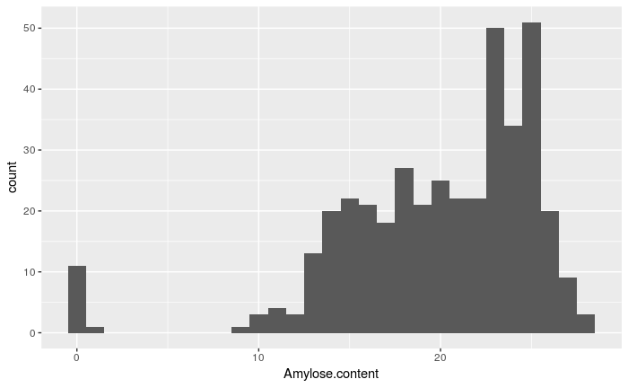

```r
pl <- ggplot(data.pheno.mds,aes(x=Amylose.content)) + geom_histogram(binwidth = 1)
pl
```

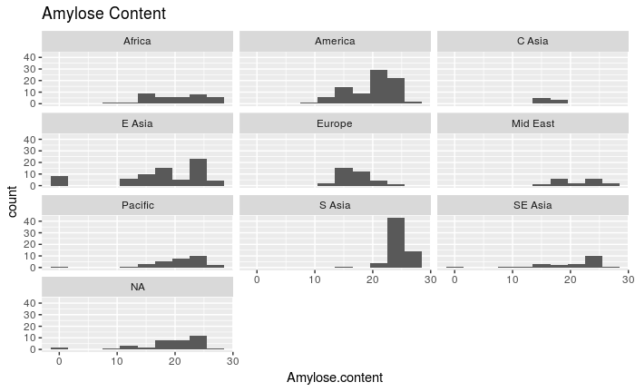

```r
pl <- ggplot(data=data.pheno.mds,aes(x=Amylose.content)) #create the basic plot object
pl <- pl + geom_histogram(binwidth=3) #tell R that we want a histogram, with binwidth of 3
pl <- pl + facet_wrap(facets= ~ Region, ncol=3) # a separate plot ("facet") for each region, arranged in 3 columns
pl <- pl + ggtitle("Amylose Content") #add a title
pl #display the plot
```

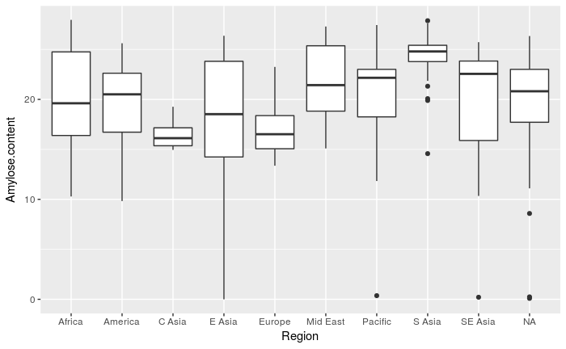

```r
pl <- ggplot(data=data.pheno.mds,aes(x=Region,y=Amylose.content)) + geom_boxplot()
pl
```

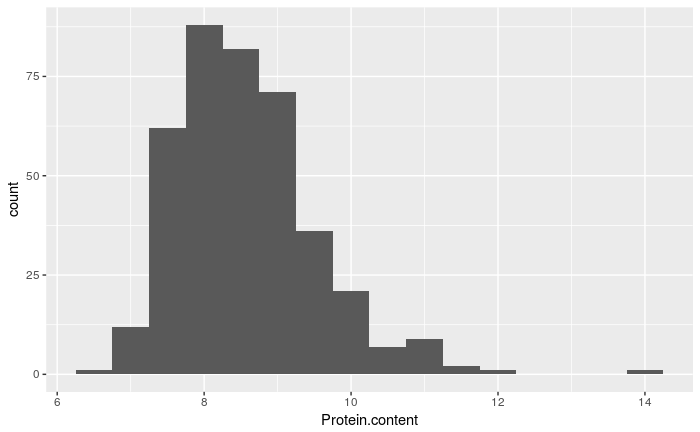

```r
# Single Histogram for all of the data
ggplot(data.pheno.mds, aes(x = Protein.content)) + geom_histogram(binwidth = 0.5)
```

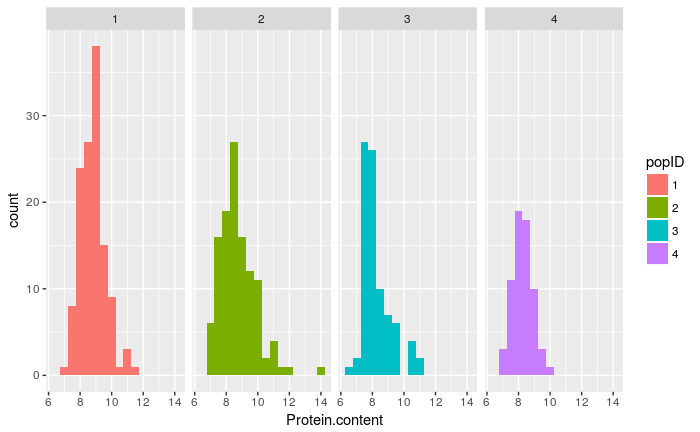

```r
# Separate histograms for each of the 4 populations
ggplot(data.pheno.mds, aes(x = Protein.content, fill = popID)) + geom_histogram(binwidth = 0.5) + facet_grid(~popID)
```

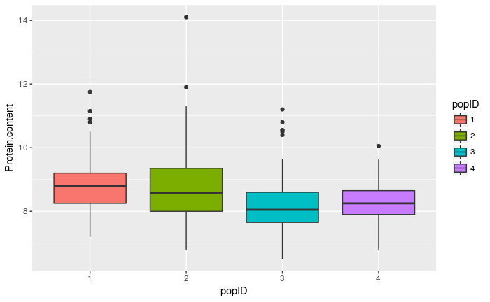

```r
# As a boxplot separated by population
ggplot(data.pheno.mds, aes(x = popID, y = Protein.content, fill = popID)) + geom_boxplot()
```

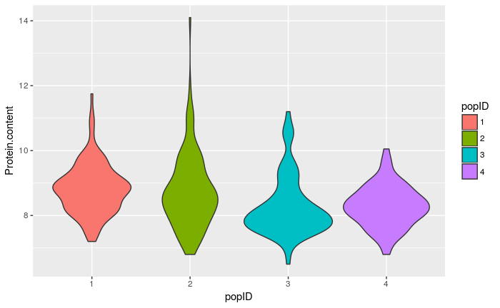

```r
# As a violin plot
ggplot(data.pheno.mds, aes(x = popID, y = Protein.content, fill = popID)) + geom_violin()
```

**Exercise 6:**

- Obtain the mean of your trait for each of the 4 PSMix populations.
- Perform an ANOVA for your trait to test if it varies significantly by population. Show your code, the ANOVA output, and provide an interpretation.
- Discuss: Do your results present a problem for GWAS?

```r
mean(data.pheno.mds$Protein.content,na.rm=T) #the na.rm argument tells R to ignore missing data coded by "NA"
```

```
[1] 8.592557
```

```r
tapply(X=data.pheno.mds$Protein.content,INDEX=data.pheno.mds$popID,FUN=min,na.rm=T)
```

```
  1   2   3   4
7.2 6.8 6.5 6.8
```

```r
#ANOVA test to check if the differences in mean we see among the diferent population is significant.
aov1 <- aov(Protein.content ~ popID,data=data.pheno.mds)
summary(aov1)
```

```
             Df Sum Sq Mean Sq F value   Pr(>F)
popID         3   24.2   8.072    9.74 3.28e-06 ***
Residuals   389  322.4   0.829
---
Signif. codes:  0 ‘***’ 0.001 ‘**’ 0.01 ‘*’ 0.05 ‘.’ 0.1 ‘ ’ 1
20 observations deleted due to missingness
```

> The ANOVA test returns a small p value of 3.28e-06. This is problematic for GWAS studies as the differences among the 4 sub populations is significant, it is a good indicator for population structure.

To be ready to perfrom a GWAS run the following:

```r
#load information about snp chromosome and position
snpinfo <- read.csv("./RiceSNPData/snpInfo.csv",row.names=1)
head(snpinfo) #note one column for chromosome and one for position (in base pairs)
```

|  | snp | chr | pos |
| --- | --- | --- | --- |
| 1 | X1_13147 | 1 | 13147 |
| 2 | X1_73192 | 1 | 73192 |
| 3 | X1_74969 | 1 | 74969 |
| 4 | X1_75852 | 1 | 75852 |
| 5 | X1_75953 | 1 | 75953 |
| 6 | X1_91016 | 1 | 91016 |

```r
# you will need the data.geno file from the previous lab.  If you don't have it in your workspace, reload it
data.geno <- read.csv("./RiceSNPData/Rice_44K_genotypes.csv.gz", row.names=1, na.strings=c("NA","00"))
#next merge the genotype information with the phenotype and population info:
head(data.pheno.mds) #note: need to get rownames assigned correctly again (they were lost after the merge)
```

|  | Row.names | V1 | V2 | popID | pr1 | pr2 | pr3 | pr4 | Accession_Name | Country_of_Origin | Region | Alu.Tol | Flowering.time.at.Arkansas | Flowering.time.at.Faridpur | Flowering.time.at.Aberdeen | FT.ratio.of.Arkansas.Aberdeen | FT.ratio.of.Faridpur.Aberdeen | Culm.habit | Leaf.pubescence | Flag.leaf.length | Flag.leaf.width | Awn.presence | Panicle.number.per.plant | Plant.height | Panicle.length | Primary.panicle.branch.number | Seed.number.per.panicle | Florets.per.panicle | Panicle.fertility | … |
| --- | --- | --- | --- | --- | --- | --- | --- | --- | --- | --- | --- | --- | --- | --- | --- | --- | --- | --- | --- | --- | --- | --- | --- | --- | --- | --- | --- | --- | --- | --- |
| 1 | NSFTV1 | 16.56953 | -1.0787988 | 2 | 3.906153e-74 | 1.000000e+00 | 4.940656e-324 | 4.940656e-324 | Agostano | Italy | Europe | 0.730 | 75.08333 | 64 | 81 | 0.9269547 | 0.7901235 | 4.000000 | 1 | 28.37500 | 1.283333 | 0 | 3.068053 | 110.91667 | 20.48182 | 9.272727 | 4.785975 | 4.914658 | 0.879 | … |
| 2 | NSFTV10 | 17.04054 | -0.8204474 | 2 | 5.975221e-105 | 1.000000e+00 | 0.000000e+00 | 0.000000e+00 | Baghlani Nangarhar | Afghanistan | Mid East | 0.902 | 89.00000 | 55 | 74 | 1.2027027 | 0.7432432 | 3.000000 | NA | 27.90000 | 1.000000 | 1 | 3.650658 | 83.00000 | 22.16667 | 10.333333 | 4.110874 | 4.733270 | 0.537 | … |
| 3 | NSFTV100 | 15.11382 | 1.4328584 | 2 | 4.524589e-01 | 5.475411e-01 | 1.486226e-251 | 5.413008e-254 | Lacrosse | United States | America | 0.800 | 84.11111 | 78 | 122 | 0.6894353 | 0.6393443 | 1.666667 | 0 | 27.62222 | 1.611111 | 0 | 2.978925 | 114.88889 | 23.94444 | 11.555556 | 5.032614 | 5.340738 | 0.735 | … |
| 4 | NSFTV101 | 11.42892 | 2.3895538 | 1 | 9.279480e-01 | 3.621048e-02 | 3.584154e-02 | 1.228608e-59 | Lemont | United States | America | 0.630 | 86.16667 | 79 | 88 | 0.9791667 | 0.8977273 | 3.000000 | 0 | 27.62500 | 1.450000 | 0 | 2.818398 | 86.16667 | 27.45000 | 11.083333 | 4.894101 | 5.209031 | 0.730 | … |
| 5 | NSFTV102 | -22.55710 | 10.0444979 | 3 | 2.664270e-02 | 9.945103e-07 | 9.733563e-01 | 6.766981e-74 | NA | NA | NA | 0.440 | NA | NA | 165 | NA | NA | 3.000000 | NA | 27.85000 | 1.100000 | 1 | 3.481240 | 105.50000 | 30.75000 | 10.500000 | 4.600158 | 4.867534 | 0.765 | … |
| 6 | NSFTV103 | 15.72071 | 0.2261091 | 2 | 5.139445e-02 | 9.121458e-01 | 3.645977e-02 | 4.916478e-141 | Luk Takhar | Afghanistan | Mid East | 0.550 | 84.00000 | 78 | 108 | 0.7777778 | 0.7222222 | 2.500000 | 1 | 30.17500 | 1.050000 | 0 | 2.957511 | 95.08333 | 24.13333 | 9.777778 | 4.881538 | 4.998900 | 0.889 | … |

```r
rownames(data.pheno.mds) <- data.pheno.mds$Row.names
data.geno.pheno <- merge(data.pheno.mds,data.geno,by="row.names")
```

```
column name ‘Row.names’ is duplicated in the result
```

```r
#you can ignore the warning
```

```r
library(SNPassoc) #load the package that does the associations
#if you get an error that the package is not available, use install.packages("SNPassoc") to install it.
#create new data frames containing only chromosome 3 information.
#grep() is the R version of the linux grep command that you saw in Ian's section.  So the command below extracts columns 1:47 and all chromosome 3 genotype columns
data.geno.pheno3 <- data.geno.pheno[,c(1:47,grep("X3_",colnames(data.geno.pheno)))]
snpinfo3 <- snpinfo[snpinfo$chr==3,]
#convert SNPinfo to a format that SNPassoc can use
snps3 <- setupSNP(data.geno.pheno3,48:ncol(data.geno.pheno3),sort=T,info=snpinfo3,sep="")
```

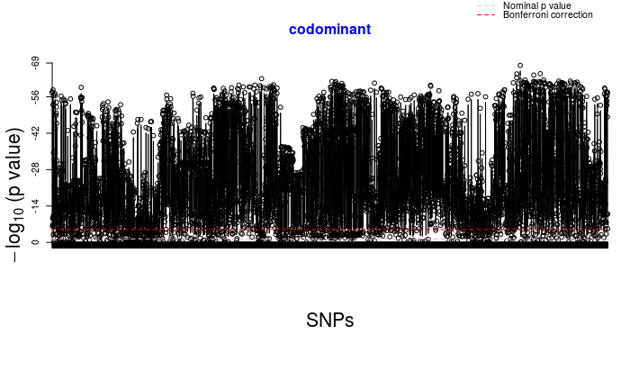

```r
#analysis without population structure correction
#this takes ~ 5 minutes to run.
wg3 <- WGassociation(Alu.Tol,data=snps3,model="co",genotypingRate=50)
plot(wg3,print.label.SNPs=FALSE)
```

```r
#the p-values for the co-dominant model are extracted by using the codominant() function
#determine the number of significant SNPs (p < 0.00001):
sum(codominant(wg3) < 1e-5)
```

```
[1] 3664
```

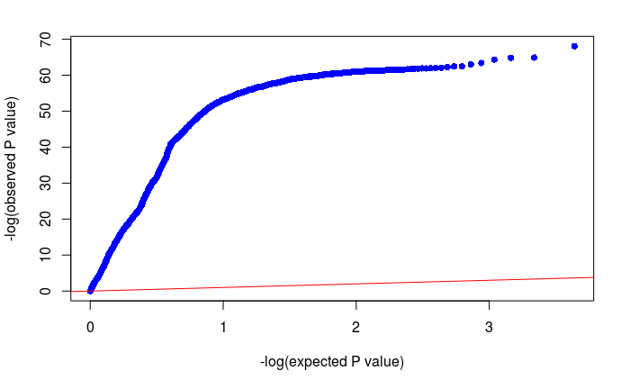

```r
qqpval(codominant(wg3)) #remember that codominant(wg3) returns the observed p-values.
```

> There is inflation in the observed P value vs the expected P value, which is good indication of population structure giving us false positives.

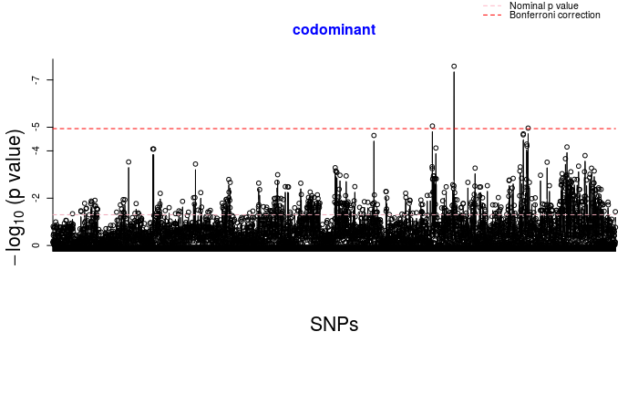

```r
#analysis with population structure correction:
wg3.corrected <- WGassociation(Alu.Tol ~ pr1 + pr2 + pr3 + pr4,data=snps3,model="co",genotypingRate=50)
#analysis with population structure correction.
plot(wg3.corrected,print.label.SNPs=FALSE)
```

```r
sum(codominant(wg3.corrected) < 1e-5)
```

```
[1] 2
```

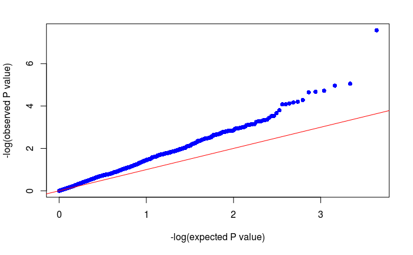

```r
qqpval(codominant(wg3.corrected))
```

**Exercise 7:** Describe and discuss the differences in the analysis with and without population structure correction. Which do you think is the better one to follow-up on, and why?

> When there is population structure the results are inflated with false positive hits of significant SNPs. A population may have diverged and accumulated certain SNP genotypes which is not shared among other populations, thus we cannot compare these SNPs between populations. Taking population structure into account, we see that the results of observed P values are much closer to the expected P values. The difference between the two is significant as the previous test returned 3664 significant SNPs while the adjusted test returned 2 significant SNPs. It is better to study the SNPs returned by the test corrected for population structure as these SNPs are better representive of significant SNPs.

```r
#use the square bracked extractions command to extract all rows where the SNP p-value is less than 1e-5
snpinfo3[codominant(wg3.corrected) < 1e-5,]
```

|  | snp | chr | pos |
| --- | --- | --- | --- |
| 13279 | X3_27639188 | 3 | 27639188 |
| 13447 | X3_27753936 | 3 | 27753936 |

```r
#if we want to add the pvals to the output:
cbind(snpinfo3[codominant(wg3.corrected) < 1e-5,],codominant(wg3.corrected)[codominant(wg3.corrected) < 1e-5])
```

|  | snp | chr | pos | codominant(wg3.corrected)[codominant(wg3.corrected) < 1e-05] |
| --- | --- | --- | --- | --- |
| 13279 | X3_27639188 | 3 | 27639188 | 8.889402e-06 |
| 13447 | X3_27753936 | 3 | 27753936 | 2.643791e-08 |

**Exercise 8:** Look for genes close to your SNP at the [rice genome browser](http://rice.plantbiology.msu.edu/cgi-bin/gbrowse/rice/). Pick a significant SNP from your analysis and enter its chromosome and position in the search box. The browser wants you to enter a start and stop position, so for example, you should enter “Chr3:30449857..30449857” and then choose “show 20kb” from the pulldown menu on the left hand side. Report the SNP you chose and the three closest genes. These are candidate genes for determining the phenotype of your trait of interest in the rice population. Briefly discuss these genes as possible candidates for the GWAS peak. (Include a screenshot of the genome browser)

> Search for SNP chr 3 position 27639188. The 3 closest genes I found were LOC_Os03g48480, LOS_Os03g48490, LOS_Os03g48520. Looking up the function of LOC_Os03g48480, the gene is involved in metabolic process, found in the peroxisome, and has a hydrolase activity.The proteins hydrolase activity may be playing some role in neutralizing or decreasing the toxicity of the aluminium. LOS_Os03g48490 is a centromeric protein that is involved with sequence specific DNA binding. This protein may be involved with activating certain genes that can increase resistance to aluminium. LOS_Os03g48520 is a protein that contains a protein binding domain. This protein could bind to another protein to form a complex that has a enzymatic function that neutralizes or decreases aluminium toxicity.